# 25_unit_circ_intro

## 25_unit_circ_intro

#### Question

1. The [unit circle](https://en.wikipedia.org/wiki/Unit_circle) below has a radius of length 1. The coordinates of special angles are shown.

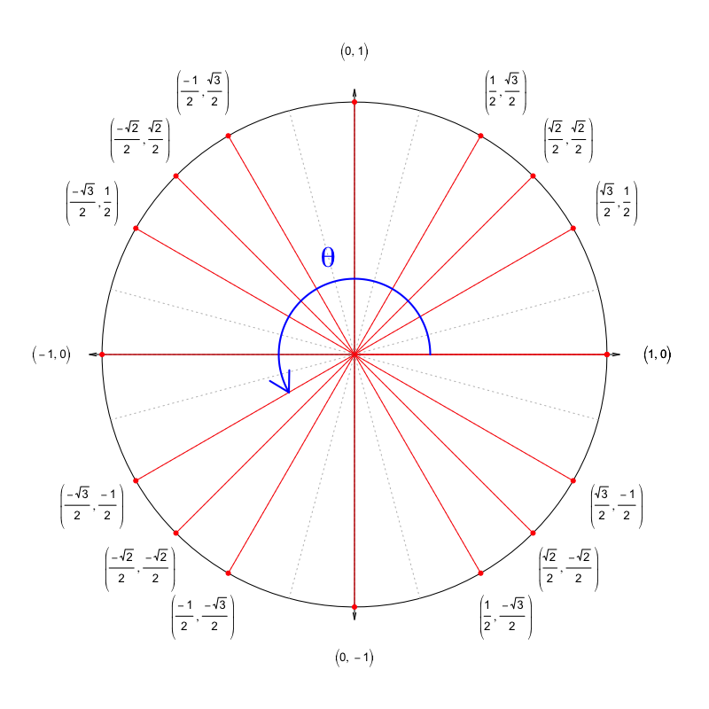

   Determine $\sin\left(\theta\right)$.
   1. $-1$
   2. $\frac{-\sqrt{3}}{2}$
   3. $\frac{-\sqrt{2}}{2}$
   4. $\frac{-1}{2}$
   5. $0$
   6. $\frac{1}{2}$
   7. $\frac{\sqrt{2}}{2}$
   8. $\frac{\sqrt{3}}{2}$
   9. $1$

#### Solution

#### Question

2. The [unit circle](https://en.wikipedia.org/wiki/Unit_circle) below has a radius of length 1. The coordinates of special angles are shown.

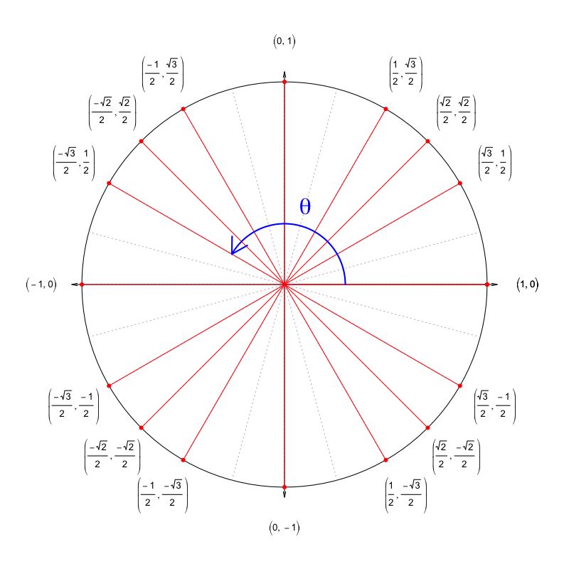

   Determine $\cos\left(\theta\right)$.
   1. $-1$
   2. $\frac{-\sqrt{3}}{2}$
   3. $\frac{-\sqrt{2}}{2}$
   4. $\frac{-1}{2}$
   5. $0$
   6. $\frac{1}{2}$
   7. $\frac{\sqrt{2}}{2}$
   8. $\frac{\sqrt{3}}{2}$
   9. $1$

#### Solution

#### Question

3. The [unit circle](https://en.wikipedia.org/wiki/Unit_circle) below has a radius of length 1. The coordinates of special angles are shown.

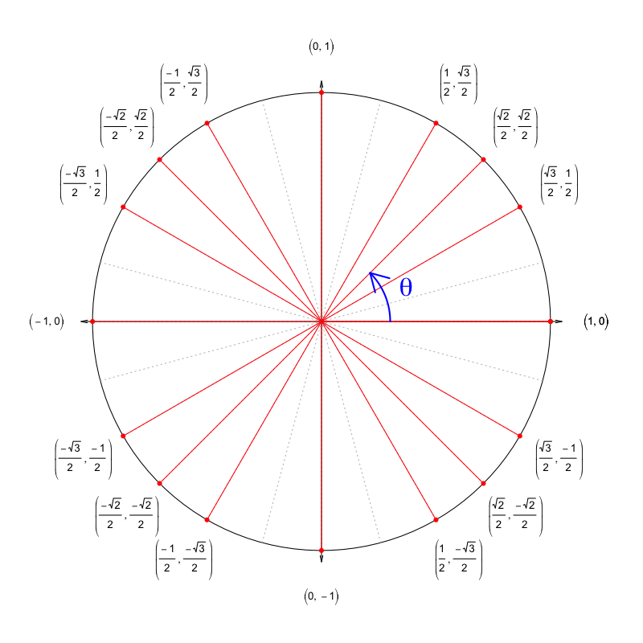

   Determine $\cos\left(\theta\right)$.
   1. $-1$
   2. $\frac{-\sqrt{3}}{2}$
   3. $\frac{-\sqrt{2}}{2}$
   4. $\frac{-1}{2}$
   5. $0$
   6. $\frac{1}{2}$
   7. $\frac{\sqrt{2}}{2}$
   8. $\frac{\sqrt{3}}{2}$
   9. $1$

#### Solution

#### Question

4. The [unit circle](https://en.wikipedia.org/wiki/Unit_circle) below has a radius of length 1. The coordinates of special angles are shown.

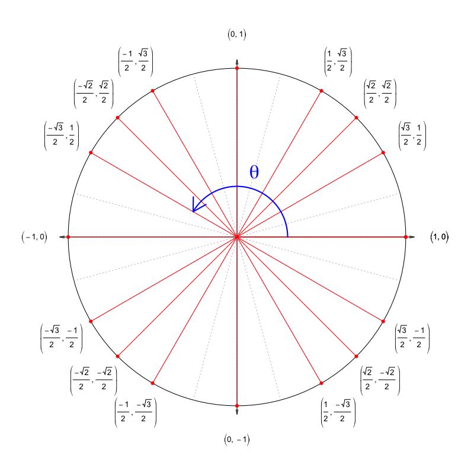

   Determine $\cos\left(\theta\right)$.
   1. $-1$
   2. $\frac{-\sqrt{3}}{2}$
   3. $\frac{-\sqrt{2}}{2}$
   4. $\frac{-1}{2}$
   5. $0$
   6. $\frac{1}{2}$
   7. $\frac{\sqrt{2}}{2}$
   8. $\frac{\sqrt{3}}{2}$
   9. $1$

#### Solution

#### Question

5. The [unit circle](https://en.wikipedia.org/wiki/Unit_circle) below has a radius of length 1. The coordinates of special angles are shown.

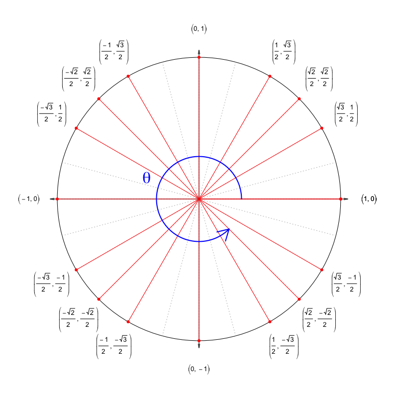

   Determine $\sin\left(\theta\right)$.
   1. $-1$
   2. $\frac{-\sqrt{3}}{2}$
   3. $\frac{-\sqrt{2}}{2}$
   4. $\frac{-1}{2}$
   5. $0$
   6. $\frac{1}{2}$
   7. $\frac{\sqrt{2}}{2}$
   8. $\frac{\sqrt{3}}{2}$
   9. $1$

#### Solution

#### Question

6. The [unit circle](https://en.wikipedia.org/wiki/Unit_circle) below has a radius of length 1. The coordinates of special angles are shown.

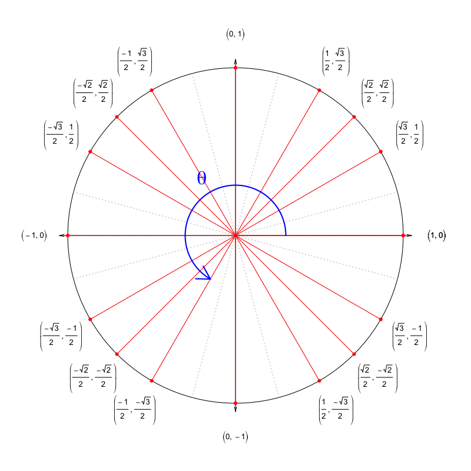

   Determine $\cos\left(\theta\right)$.
   1. $-1$
   2. $\frac{-\sqrt{3}}{2}$
   3. $\frac{-\sqrt{2}}{2}$
   4. $\frac{-1}{2}$
   5. $0$
   6. $\frac{1}{2}$
   7. $\frac{\sqrt{2}}{2}$
   8. $\frac{\sqrt{3}}{2}$
   9. $1$

#### Solution

#### Question

7. The [unit circle](https://en.wikipedia.org/wiki/Unit_circle) below has a radius of length 1. The coordinates of special angles are shown.

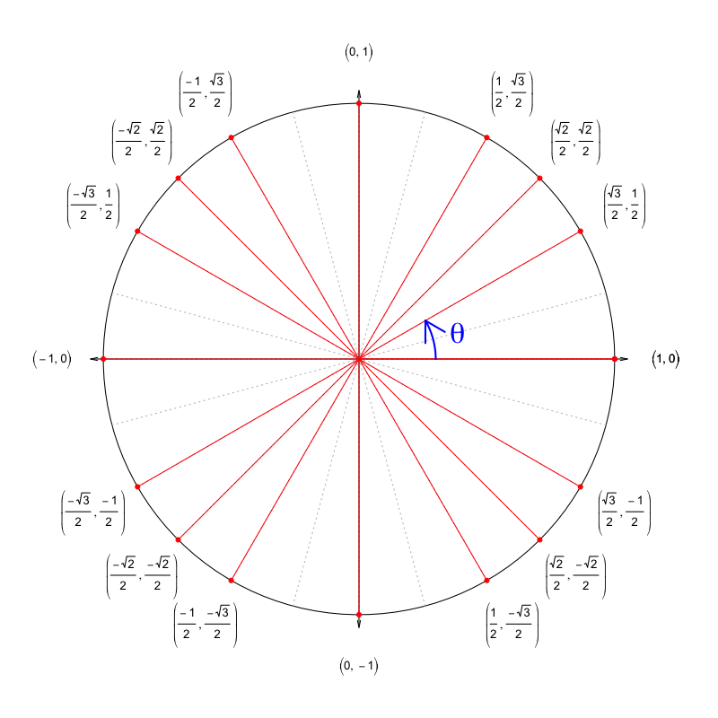

   Determine $\cos\left(\theta\right)$.
   1. $-1$
   2. $\frac{-\sqrt{3}}{2}$
   3. $\frac{-\sqrt{2}}{2}$
   4. $\frac{-1}{2}$
   5. $0$
   6. $\frac{1}{2}$
   7. $\frac{\sqrt{2}}{2}$
   8. $\frac{\sqrt{3}}{2}$
   9. $1$

#### Solution

#### Question

8. The [unit circle](https://en.wikipedia.org/wiki/Unit_circle) below has a radius of length 1. The coordinates of special angles are shown.

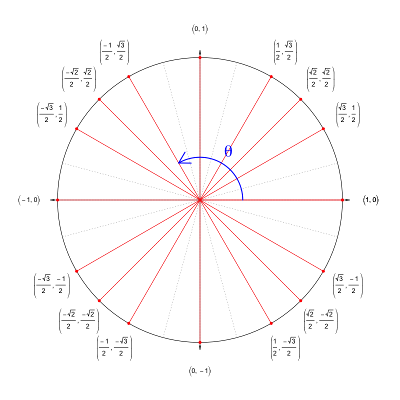

   Determine $\sin\left(\theta\right)$.
   1. $-1$
   2. $\frac{-\sqrt{3}}{2}$
   3. $\frac{-\sqrt{2}}{2}$
   4. $\frac{-1}{2}$
   5. $0$
   6. $\frac{1}{2}$
   7. $\frac{\sqrt{2}}{2}$
   8. $\frac{\sqrt{3}}{2}$
   9. $1$

#### Solution